# Is Airbnb profitable business?

# Minimum nights and estimated revenue are correlated?

```python
# Estimated revenue
estimated_revenue =  AIRBNB_DT
estimated_revenue['Estimated_revenue'] = AIRBNB_DT['price'] * AIRBNB_DT['minimum_nights']
```

```python
estimated_revenue['Estimated_revenue'].corr(estimated_revenue['minimum_nights'])
```

```
0.33477498861420707
```

Minimum nights and estimated revenue are 33% correlated with each other.

## Room Type list

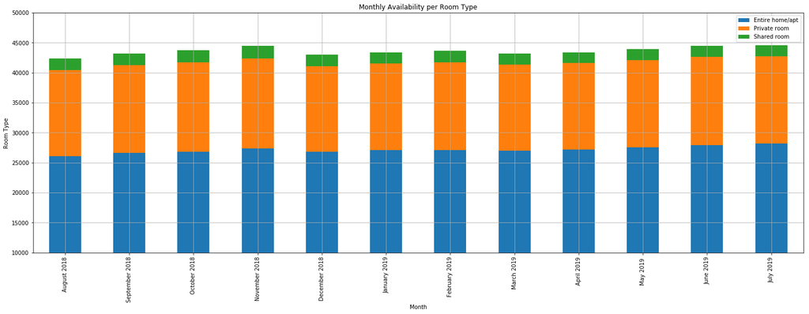

```python
city.room_type([0,0],[10000,50000])
```

## Bedrooms per propertie

|  | Bedrooms | # of Properties |
| --- | --- | --- |
| 0 | 0.0 | 56,372.00 |
| 1 | 1.0 | 307,432.00 |
| 2 | 2.0 | 91,921.00 |
| 3 | 3.0 | 39,735.00 |
| 4 | 4.0 | 16,541.00 |
| 5 | 5.0 | 7,099.00 |
| 6 | 6.0 | 2,151.00 |

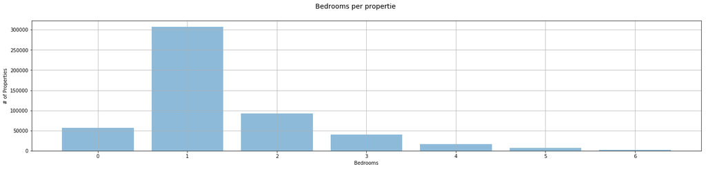

```python
city.bedrooms([0,0],[0,0])
```

- Renting a place with one or 2 bedrooms seems to give the host good rentals.

# If you want to take advantage of this new industry and translate it into a business opportunity. What are the key factors you should take into account?

### Let's check!

## Avg price per room type

- First, let's see which are the room types that are rented for a higher price.

|  | Room Type | Price |
| --- | --- | --- |
| 0 | Entire home/apt | $269.87 |
| 1 | Private room | $86.00 |
| 2 | Shared room | $51.82 |

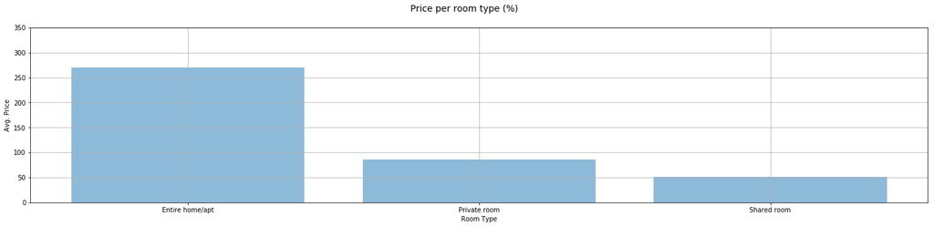

```python
city.price_type_room([0,0],[0,350])
```

Like one might imagine, Entire home/apt are the most expensive airbnb, followed by the private rooms and at the end, shared bedrooms. Just to be sure there's a consistent and significant difference between the prices of each room type, let's do a t-test.

```python
city.room_type_t_test()
```

|  | Room Type | Statistic | p-value |
| --- | --- | --- | --- |
| 0 | Entire home/apt - Private room | 152.765805 | 0.000000e+00 |
| 1 | Private room - Shared room | 19.607864 | 4.947830e-85 |

High t-stat and low p-value. We're safe, there's a significance difference between the Entire home/apt price and the private and shared bedrooms.

Then you might ask, which part of town is where high prices are observed?

## Average price per neighborhood (Top 10 - USD)

|  | Neighbourhood | Properties | Price |
| --- | --- | --- | --- |
| 0 | Malibu | 4,638.00 | $1,306.67 |
| 1 | Bel Air/Beverly Crest | 5,100.00 | $1,270.11 |
| 2 | Laurel Canyon | 3,476.00 | $839.11 |
| 3 | Beverly Hills | 6,917.00 | $597.20 |
| 4 | Pacific Palisades | 2,866.00 | $445.05 |
| 5 | Palos Verdes | 208.00 | $426.13 |
| 6 | Encino | 2,407.00 | $392.80 |
| 7 | Hollywood Hills | 9,711.00 | $366.72 |
| 8 | Manhattan Beach | 2,783.00 | $337.47 |
| 9 | Cahuenga Pass | 2,086.00 | $318.35 |

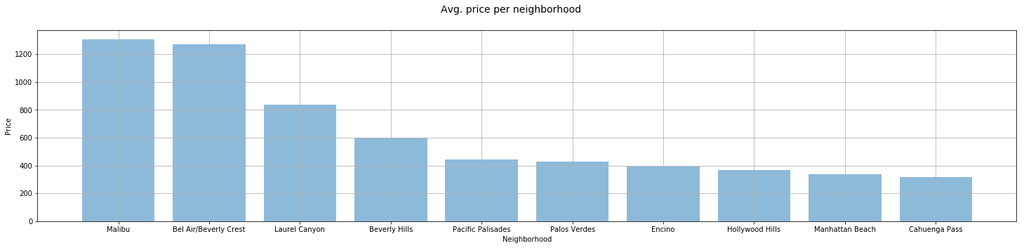

```python
#Los Angeles average price per neighborhood (to get the top 5 best neighborhoods)
city.neighborhood([0,0],[0,0],'p')
```

- These are the neighbourhoods that have the highest Avg. price and the prices for each of these neighbourhoods are significantly higher than the average price for all Airbnb listings.

### Are these prices consistently higher than the average?

```python
city.p_value_test()
```

|  | City | Statistic | p-value |
| --- | --- | --- | --- |
| 0 | Malibu | 38.755689 | 6.246721e-285 |
| 1 | Bel Air/Beverly Crest | 36.171455 | 2.913160e-255 |
| 2 | Laurel Canyon | 20.541878 | 1.346300e-88 |
| 3 | Beverly Hills | 21.981779 | 1.384482e-103 |
| 4 | Pacific Palisades | 20.644617 | 1.980607e-88 |
| 5 | Palos Verdes | 7.318458 | 5.427359e-12 |
| 6 | Encino | 10.768200 | 1.920092e-26 |
| 7 | Hollywood Hills | 24.960607 | 2.007628e-133 |
| 8 | Manhattan Beach | 20.767888 | 2.574006e-89 |
| 9 | Cahuenga Pass | 11.018876 | 1.723502e-27 |

### And what about amenities? What are the amenities an airbnb listing should offer to guarantee a high price?

```python
city.amenities()
```

|  | Item | Coefficient | R2 | p-value | Std Error |
| --- | --- | --- | --- | --- | --- |
| 11 | Pool | 191.222240 | 2.475941 | 0.000000e+00 | 1.659285 |
| 8 | Hot tub | 201.618698 | 2.299449 | 0.000000e+00 | 1.817039 |
| 12 | Free parking on premises | 101.973123 | 0.947114 | 0.000000e+00 | 1.441833 |
| 0 | TV | 106.056190 | 0.677348 | 0.000000e+00 | 1.775625 |
| 7 | Washer | 73.389162 | 0.352920 | 0.000000e+00 | 1.704994 |
| 1 | Cable TV | 64.761884 | 0.340386 | 0.000000e+00 | 1.532111 |
| 6 | Kitchen | 90.300807 | 0.299557 | 0.000000e+00 | 2.277703 |
| 5 | Gym | 70.900715 | 0.237331 | 2.734240e-272 | 2.009805 |
| 9 | Free street parking | -49.150566 | 0.217505 | 1.069084e-249 | 1.455520 |
| 3 | Air conditioning | 51.331977 | 0.185019 | 1.100044e-212 | 1.648447 |
| 10 | Heating | 35.981227 | 0.053364 | 1.100811e-62 | 2.152934 |
| 2 | Wifi | -32.409847 | 0.010372 | 1.756593e-13 | 4.399734 |
| 4 | Internet | -3.690562 | 0.001083 | 1.729491e-02 | 1.550406 |

- After running a regression with the presence or absence (binary variable) of a list of basic ammenities. We found out that the Pool, Hot tub, Free parking, TV and Washer ammenities are those that have a bigger explanatory power to "explain" the price of Airbnb listings.
- Now that we know what an Airbnb should offer, where should it be located and what type should it be. Let's focus now on the reviews. According to our analysis, reviews play an important part in the price.

```python
city.reviews()
```

|  | Coefficent | R2 | p-value | Std error |
| --- | --- | --- | --- | --- |
| 0 | 1.102121 | 0.113553 | 6.469856e-104 | 0.050899 |

There is a clear relationship between avg reviews and avg price for the cases analyzed. The better review, the higher the price.

Reviews are broken down by type of review [Accuracy, Cleanliness, Check in, Communication, Location and Value] and based on our correlation matrix, Accuracy and Value reviews are related to General Review.

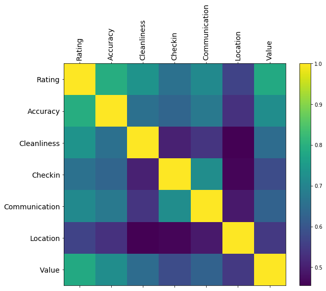

```python
#Correlation coeficient
city.correlation()
```

### Having said that, once you are operating under airbnb, focus on checking your reviews, specially the ones related to Accuracy and Value, and try to cover any holes you might find.

# Airbnb vs honest job USA

```python
Average_daily_rate =  199.18
Airbnb_month = Average_daily_rate*30
wage = pd.read_csv('csv/lbs.csv')
month_average = wage.mean(axis=1)
wage_2 = pd.DataFrame({'Airbnb monthly revenue': [5975.40], 'Average USA wage 2018': [3605.59]})
wage_2.rename(index={0:'2018'},inplace=True)
wage_2_output = wage_2.copy()
wage_2_output.applymap('${:,.2f}'.format)
```

|  | Airbnb monthly revenue | Average USA wage 2018 |
| --- | --- | --- |
| 2018 | $5,975.40 | $3,605.59 |

##### Assuming a host actually has a month full of bookings, is more profitable to be an Airbnb host than go everyday to work

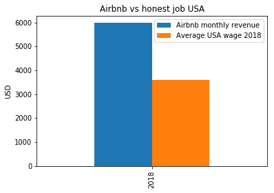

```python
wage_2.plot(kind='bar')
plt.title("Airbnb vs honest job USA")

plt.ylabel("USD")
```

# Conclussions:

##### If you are looking to have a high price airbnb listing, these are the factors you should take into account:

- Offer an entire home/apt, if you have the option, or a private room, if the first option is not available.
- Location, location, location. The cited neighbourhoods will almost guarantee you a high price.
- There is evidence stating that cited amenities have a relatively high explanatory power and important weight in the airbnb prices.
- Check your reviews. Specially the accuracy and the value reviews. Check the feedback visitors provide and try to improve constantly in these fields